# Exercise manner prediction

Rdataman

Thursday, July 24, 2014

# 1. Introduction

The goal of the project is to predict the manner of exercise by the data collected from accelerometers(Data source: http://groupware.les.inf.puc-rio.br/har.)

# 2. Raw data

Download the files and save them in the work directory. Read the data into workspace. The data has already been into training and testing sets.

```r
## Download the files if not done
url1<-"https://d396qusza40orc.cloudfront.net/predmachlearn/pml-training.csv"
url2<-"https://d396qusza40orc.cloudfront.net/predmachlearn/pml-testing.csv"
if (!file.exists("training.csv")){download.file(url1,"training.csv") }
if (!file.exists("testing.csv")){download.file(url2,"testing.csv") }
## Read the data
test<-read.csv("testing.csv")
train<-read.csv("training.csv")
```

# 3. Features

There are 160 columns in the raw data. Some of the columns are totally NAs and should be deleted. The first 7 columns have nothing to do with the exercise. They are not included in the clean data.

```r
## Delete the NA cols
test1 <- test[,colSums(is.na(test))==0]
train1 <- train[,colSums(is.na(test))==0]
## Delete the first 7 cols which is not helpful to prediction
test1 <- test1[,-c(1:7)]
train1 <- train1[,-c(1:7)]
## Cehck the number of NAs in both dataframe
sum(is.na(train1))+sum(is.na(test1))
```

```
## [1] 0
```

Clearly there are no NAs in the new data.

```r
## Check if the two dataframe has the same colnames
which(colnames(train1)!=colnames(test1))
```

```
## [1] 53
```

Only the 53rd colname is different in train (“classe”“) and test data(”problem_id“).

```r
## Check if there are zero covariates
library(caret)
nsv <- nearZeroVar(train1, saveMetrics=TRUE)
which(nsv$nzv==TRUE)
```

```
## integer(0)
```

There are no zero covariates. So we have 52 predictors.

# 4. prediction Model

## 4.1 preprocess data

Split the train1 into two parts: “TrainTr” for modeling and “trainTe” for cross validation. Preprocess the data to reduce the predictor.

```r
library(randomForest)
set.seed(10)
## Split train1
trainSP <- createDataPartition(y=train1$classe, p=0.7, list=FALSE)
trainTr <- train1[trainSP,]
trainTe <- train1[-trainSP,]
## Preprocess the data to get codes run faster
## capture only 90% of the variance
preProc <- preProcess(trainTr[,-53], method = "pca", thresh = 0.90)
trainset<-predict(preProc,trainTr[,-53])
```

## 4.2 Random forests model

```r
mfrf<-randomForest(trainTr$classe~.,data=trainset,
                   preProcess=c("center", "scale"),
                   trControl=trainControl(method = "cv", number = 10),
                   importance=TRUE)
## show the model information
mfrf
```

```
##
## Call:
##  randomForest(formula = trainTr$classe ~ ., data = trainset, preProcess = c("center",      "scale"), trControl = trainControl(method = "cv", number = 10),      importance = TRUE)
##                Type of random forest: classification
##                      Number of trees: 500
## No. of variables tried at each split: 4
##
##         OOB estimate of  error rate: 2.75%
## Confusion matrix:
##      A    B    C    D    E class.error
## A 3862   14   20    8    2     0.01126
## B   52 2554   37    6    9     0.03913
## C    7   35 2322   29    3     0.03088
## D    8    4   99 2135    6     0.05195
## E    2    7   17   13 2486     0.01545
```

The OOB estimate of error rate: 2.75%. The error rate can be decreased if preprocessing is not performed. But it take much more time to run the code.

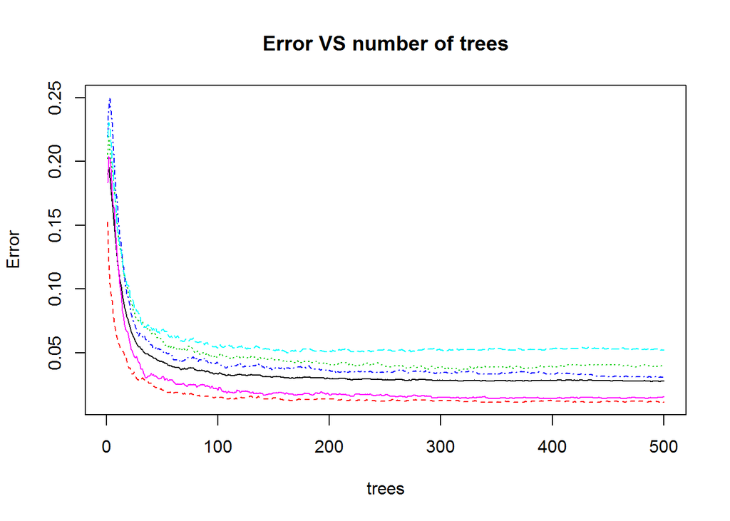

```r
plot(mfrf,main="Error VS number of trees")
```

The plot traces the error rates (out-of-bag, and by each response category) as the number of trees increases.

## 4.3 Cross-validation

Validate the model get before with the data “trainTe”

```r
testset <- predict(preProc,trainTe[,-53])
confusionMatrix(trainTe$classe, predict(mfrf,testset))
```

```
## Confusion Matrix and Statistics
##
##           Reference
## Prediction    A    B    C    D    E
##          A 1653   10    7    4    0
##          B   10 1106   20    2    1
##          C    4   22  990   10    0
##          D    1    1   47  914    1
##          E    0    4    7   10 1061
##
## Overall Statistics
##
##                Accuracy : 0.973
##                  95% CI : (0.968, 0.977)
##     No Information Rate : 0.283
##     P-Value [Acc > NIR] : <2e-16
##
##                   Kappa : 0.965
##  Mcnemar's Test P-Value : NA
##
## Statistics by Class:
##
##                      Class: A Class: B Class: C Class: D Class: E
## Sensitivity             0.991    0.968    0.924    0.972    0.998
## Specificity             0.995    0.993    0.993    0.990    0.996
## Pos Pred Value          0.987    0.971    0.965    0.948    0.981
## Neg Pred Value          0.996    0.992    0.983    0.995    1.000
## Prevalence              0.283    0.194    0.182    0.160    0.181
## Detection Rate          0.281    0.188    0.168    0.155    0.180
## Detection Prevalence    0.284    0.194    0.174    0.164    0.184
## Balanced Accuracy       0.993    0.980    0.958    0.981    0.997
```

The accuracy is 0.973, not too bad.

# 5 Prediction

```r
result0 <- predict(preProc,test1[,-53])
result <- predict(mfrf,result0)
result
```

```
##  1  2  3  4  5  6  7  8  9 10 11 12 13 14 15 16 17 18 19 20
##  B  A  B  A  A  E  D  B  A  A  B  C  B  A  E  E  A  B  B  B
## Levels: A B C D E
```